# Mini Assignment - Module8

Arindam Roy

11/30/2023

## Loading Library and Functions

```r
library(tidyverse)
#install.packages('e1071')
library(e1071)
# Confusion Matrix function
my_confusion_matrix <- function(cf_table) {
  true_positive <- cf_table[4]
  true_negative <- cf_table[1]
  false_positive <- cf_table[2]
  false_negative <- cf_table[3]
  accuracy <- (true_positive + true_negative) / (true_positive + true_negative + false_positive + false_negative)
  sensitivity_recall <- true_positive / (true_positive + false_negative)
  specificity_selectivity <- true_negative / (true_negative + false_positive)
  precision <- true_positive / (true_positive + false_positive)
  neg_pred_value <- true_negative/(true_negative + false_negative)
  print(cf_table)
  my_list <- list(sprintf("%1.0f = True Positive (TP), Hit", true_positive),
                  sprintf("%1.0f = True Negative (TN), Rejection", true_negative),
                  sprintf("%1.0f = False Positive (FP), Type 1 Error", false_positive),
                  sprintf("%1.0f = False Negative (FN), Type 2 Error", false_negative),
                  sprintf("%1.4f = Accuracy (TP+TN/(TP+TN+FP+FN))", accuracy),
                  sprintf("%1.4f = Sensitivity, Recall, Hit Rate, True Positive Rate (How many positives did the model get right? TP/(TP+FN))", sensitivity_recall),
                  sprintf("%1.4f = Specificity, Selectivity, True Negative Rate (How many negatives did the model get right? TN/(TN+FP))", specificity_selectivity),
                  sprintf("%1.4f = Precision, Positive Predictive Value (How good are the model's positive predictions? TP/(TP+FP))", precision),
                  sprintf("%1.4f = Negative Predictive Value (How good are the model's negative predictions? TN/(TN+FN)", neg_pred_value)
  )
  return(my_list)
}
```

# Load the data from Kaggle dataset

```r
df <- read_csv("Churn_Modelling.csv")
```

# Summary

```r
str(df)
```

```
## spc_tbl_ [10,000 × 14] (S3: spec_tbl_df/tbl_df/tbl/data.frame)
##  $ RowNumber      : num [1:10000] 1 2 3 4 5 6 7 8 9 10 ...
##  $ CustomerId     : num [1:10000] 15634602 15647311 15619304 15701354 15737888 ...
##  $ Surname        : chr [1:10000] "Hargrave" "Hill" "Onio" "Boni" ...
##  $ CreditScore    : num [1:10000] 619 608 502 699 850 645 822 376 501 684 ...
##  $ Geography      : chr [1:10000] "France" "Spain" "France" "France" ...
##  $ Gender         : chr [1:10000] "Female" "Female" "Female" "Female" ...
##  $ Age            : num [1:10000] 42 41 42 39 43 44 50 29 44 27 ...
##  $ Tenure         : num [1:10000] 2 1 8 1 2 8 7 4 4 2 ...
##  $ Balance        : num [1:10000] 0 83808 159661 0 125511 ...
##  $ NumOfProducts  : num [1:10000] 1 1 3 2 1 2 2 4 2 1 ...
##  $ HasCrCard      : num [1:10000] 1 0 1 0 1 1 1 1 0 1 ...
##  $ IsActiveMember : num [1:10000] 1 1 0 0 1 0 1 0 1 1 ...
##  $ EstimatedSalary: num [1:10000] 101349 112543 113932 93827 79084 ...
##  $ Exited         : num [1:10000] 1 0 1 0 0 1 0 1 0 0 ...
##  - attr(*, "spec")=
##   .. cols(
##   ..   RowNumber = col_double(),
##   ..   CustomerId = col_double(),
##   ..   Surname = col_character(),
##   ..   CreditScore = col_double(),
##   ..   Geography = col_character(),
##   ..   Gender = col_character(),
##   ..   Age = col_double(),
##   ..   Tenure = col_double(),
##   ..   Balance = col_double(),
##   ..   NumOfProducts = col_double(),
##   ..   HasCrCard = col_double(),
##   ..   IsActiveMember = col_double(),
##   ..   EstimatedSalary = col_double(),
##   ..   Exited = col_double()
##   .. )
##  - attr(*, "problems")=<externalptr>
```

# Head rows

```r
head(df)
```

```
## # A tibble: 6 × 14
##   RowNumber CustomerId Surname CreditScore Geography Gender   Age Tenure Balance
##       <dbl>      <dbl> <chr>         <dbl> <chr>     <chr>  <dbl>  <dbl>   <dbl>
## 1         1   15634602 Hargra…         619 France    Female    42      2      0
## 2         2   15647311 Hill            608 Spain     Female    41      1  83808.
## 3         3   15619304 Onio            502 France    Female    42      8 159661.
## 4         4   15701354 Boni            699 France    Female    39      1      0
## 5         5   15737888 Mitche…         850 Spain     Female    43      2 125511.
## 6         6   15574012 Chu             645 Spain     Male      44      8 113756.
## # ℹ 5 more variables: NumOfProducts <dbl>, HasCrCard <dbl>,
## #   IsActiveMember <dbl>, EstimatedSalary <dbl>, Exited <dbl>
```

# Summary

```r
summary(df)
```

```
##    RowNumber       CustomerId         Surname           CreditScore
##  Min.   :    1   Min.   :15565701   Length:10000       Min.   :350.0
##  1st Qu.: 2501   1st Qu.:15628528   Class :character   1st Qu.:584.0
##  Median : 5000   Median :15690738   Mode  :character   Median :652.0
##  Mean   : 5000   Mean   :15690941                      Mean   :650.5
##  3rd Qu.: 7500   3rd Qu.:15753234                      3rd Qu.:718.0
##  Max.   :10000   Max.   :15815690                      Max.   :850.0
##   Geography            Gender               Age            Tenure
##  Length:10000       Length:10000       Min.   :18.00   Min.   : 0.000
##  Class :character   Class :character   1st Qu.:32.00   1st Qu.: 3.000
##  Mode  :character   Mode  :character   Median :37.00   Median : 5.000
##                                        Mean   :38.92   Mean   : 5.013
##                                        3rd Qu.:44.00   3rd Qu.: 7.000
##                                        Max.   :92.00   Max.   :10.000
##     Balance       NumOfProducts    HasCrCard      IsActiveMember
##  Min.   :     0   Min.   :1.00   Min.   :0.0000   Min.   :0.0000
##  1st Qu.:     0   1st Qu.:1.00   1st Qu.:0.0000   1st Qu.:0.0000
##  Median : 97199   Median :1.00   Median :1.0000   Median :1.0000
##  Mean   : 76486   Mean   :1.53   Mean   :0.7055   Mean   :0.5151
##  3rd Qu.:127644   3rd Qu.:2.00   3rd Qu.:1.0000   3rd Qu.:1.0000
##  Max.   :250898   Max.   :4.00   Max.   :1.0000   Max.   :1.0000
##  EstimatedSalary         Exited
##  Min.   :    11.58   Min.   :0.0000
##  1st Qu.: 51002.11   1st Qu.:0.0000
##  Median :100193.91   Median :0.0000
##  Mean   :100090.24   Mean   :0.2037
##  3rd Qu.:149388.25   3rd Qu.:0.0000
##  Max.   :199992.48   Max.   :1.0000
```

## Data cleaning

```r
ColumnsNotUsed <- df %>%
  select(RowNumber, CustomerId, Surname, HasCrCard, Tenure, Balance, EstimatedSalary)

custchurn <- df %>% select(-RowNumber, -CustomerId, -Surname, -HasCrCard, -Tenure, -Balance, -EstimatedSalary)
head(custchurn)
```

```
## # A tibble: 6 × 7
##   CreditScore Geography Gender   Age NumOfProducts IsActiveMember Exited
##         <dbl> <chr>     <chr>  <dbl>         <dbl>          <dbl>  <dbl>
## 1         619 France    Female    42             1              1      1
## 2         608 Spain     Female    41             1              1      0
## 3         502 France    Female    42             3              0      1
## 4         699 France    Female    39             2              0      0
## 5         850 Spain     Female    43             1              1      0
## 6         645 Spain     Male      44             2              0      1
```

## Check if NAs are there in the data

```r
apply(custchurn, 2, function(x) any(is.na(x)))
```

```
##    CreditScore      Geography         Gender            Age  NumOfProducts
##          FALSE          FALSE          FALSE          FALSE          FALSE
## IsActiveMember         Exited
##          FALSE          FALSE
```

# Looking at the Bar chart to understand the customer chrun data available in dataset

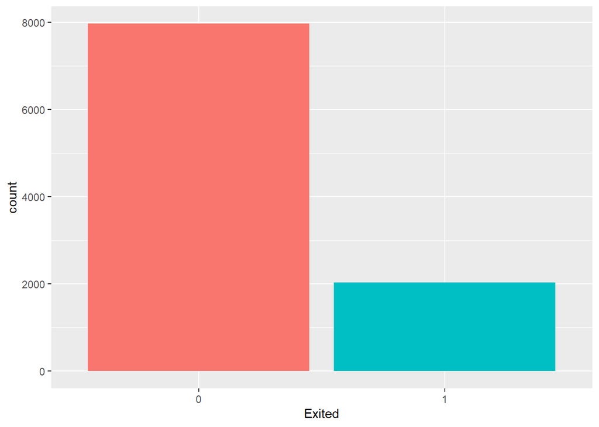

```r
custchurn <- custchurn %>% mutate(Geography = as.factor(Geography),
           Gender = as.factor(Gender),
           NumOfProducts = as.factor(NumOfProducts),
           IsActiveMember = as.factor(IsActiveMember),
           Exited = as.factor(Exited))

ggplot(custchurn, aes(Exited, fill = Exited)) +
    geom_bar() +
    theme(legend.position = 'none')
```

```r
table(custchurn$Exited)
```

```
##
##    0    1
## 7963 2037
```

# Numerical Data Distribution in dataset

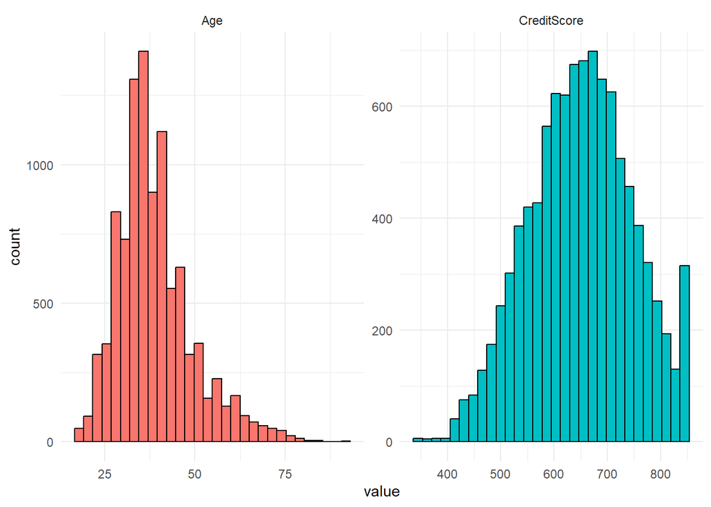

```r
custchurn %>%
    keep(is.numeric) %>%
    gather() %>%
    ggplot() +
    geom_histogram(mapping = aes(x=value,fill=key), color="black") +
    facet_wrap(~ key, scales = "free") +
    theme_minimal() +
    theme(legend.position = 'none')
```

# Correlation Matrix

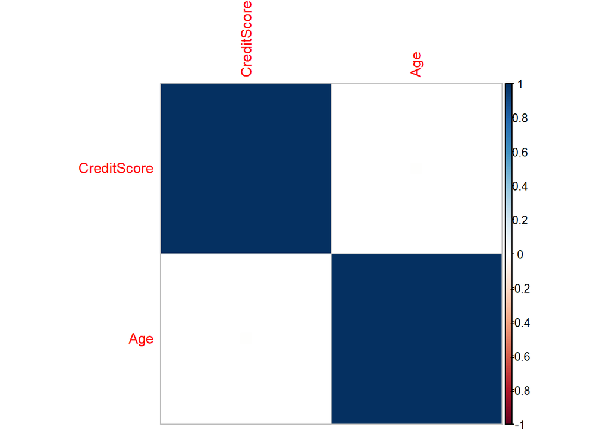

```r
#install.packages("corrplot")
library(corrplot)
numericVarName <- names(which(sapply(custchurn, is.numeric)))
corr <- cor(df[,numericVarName], use = 'pairwise.complete.obs')
corrplot(corr, method = "square")
```

# Categorical data distribution

```r
summary(custchurn)
```

```
##   CreditScore      Geography       Gender          Age        NumOfProducts
##  Min.   :350.0   France :5014   Female:4543   Min.   :18.00   1:5084
##  1st Qu.:584.0   Germany:2509   Male  :5457   1st Qu.:32.00   2:4590
##  Median :652.0   Spain  :2477                 Median :37.00   3: 266
##  Mean   :650.5                                Mean   :38.92   4:  60
##  3rd Qu.:718.0                                3rd Qu.:44.00
##  Max.   :850.0                                Max.   :92.00
##  IsActiveMember Exited
##  0:4849         0:7963
##  1:5151         1:2037
##
##
##
##
```

[output not shown]

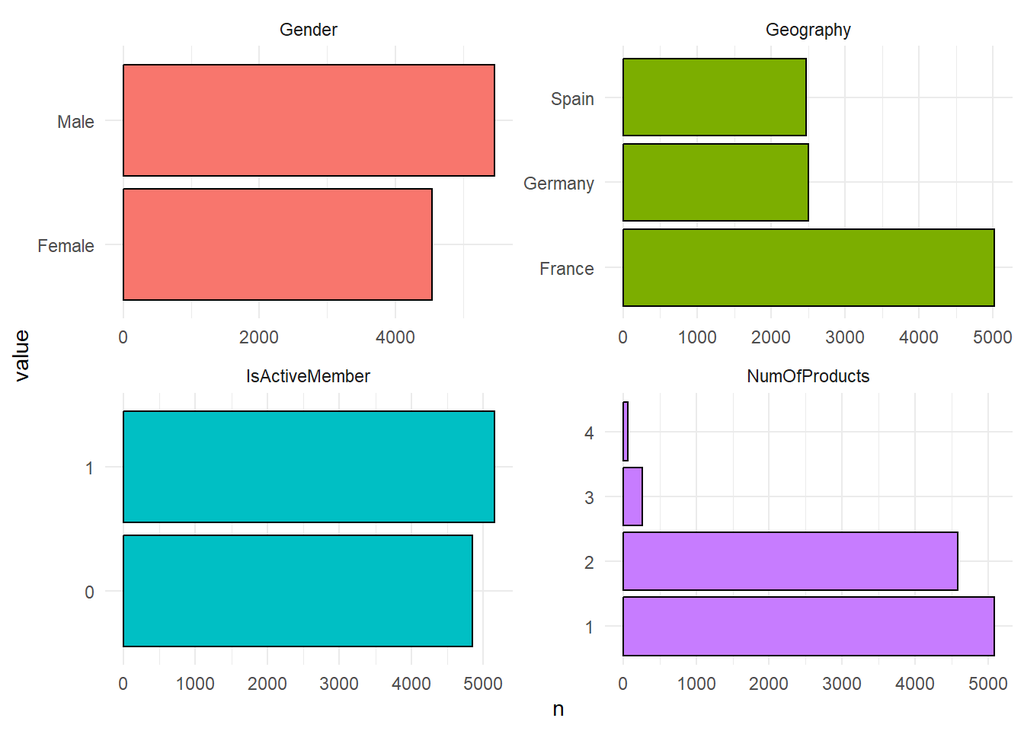

```r
custchurn %>%
    select(-Exited) %>%
    keep(is.factor) %>%
    gather() %>%
    group_by(key, value) %>%
    summarize(n = n()) %>%
    ggplot() +
    geom_bar(mapping=aes(x = value, y = n, fill=key), color="black", stat='identity') +
    coord_flip() +
    facet_wrap(~ key, scales = "free") +
    theme_minimal() +
    theme(legend.position = 'none')
```

```r
head(custchurn)
```

```
## # A tibble: 6 × 7
##   CreditScore Geography Gender   Age NumOfProducts IsActiveMember Exited
##         <dbl> <fct>     <fct>  <dbl> <fct>         <fct>          <fct>
## 1         619 France    Female    42 1             1              1
## 2         608 Spain     Female    41 1             1              0
## 3         502 France    Female    42 3             0              1
## 4         699 France    Female    39 2             0              0
## 5         850 Spain     Female    43 1             1              0
## 6         645 Spain     Male      44 2             0              1
```

# Distributing Train data and Test Data (75:25 ratio)

```r
library(caret)
set.seed(42)
partition <- caret::createDataPartition(y=custchurn$Exited, p=.75, list=FALSE) #gives matrix of row numbers
data_train <- custchurn[partition, ] #keeps the rows indicated in `partition` and all columns from `logit1`
data_test <- custchurn[-partition, ] #keeps the rows not indicated in `partition` and all columns from `logit1`
```

# Train the model using Logistic Regression algorithm

```r
model_train <- glm(Exited ~ ., family=binomial, data=data_train)
summary(model_train)
```

```
##
## Call:
## glm(formula = Exited ~ ., family = binomial, data = data_train)
##
## Coefficients:
##                    Estimate Std. Error z value Pr(>|z|)
## (Intercept)      -2.839e+00  2.648e-01 -10.723   <2e-16 ***
## CreditScore      -6.919e-04  3.460e-04  -1.999   0.0456 *
## GeographyGermany  8.959e-01  7.746e-02  11.566   <2e-16 ***
## GeographySpain    3.466e-02  8.828e-02   0.393   0.6946
## GenderMale       -6.070e-01  6.789e-02  -8.940   <2e-16 ***
## Age               6.956e-02  3.161e-03  22.006   <2e-16 ***
## NumOfProducts2   -1.522e+00  7.848e-02 -19.392   <2e-16 ***
## NumOfProducts3    2.507e+00  2.039e-01  12.294   <2e-16 ***
## NumOfProducts4    1.632e+01  2.102e+02   0.078   0.9381
## IsActiveMember1  -1.087e+00  7.162e-02 -15.175   <2e-16 ***
## ---
## Signif. codes:  0 '***' 0.001 '**' 0.01 '*' 0.05 '.' 0.1 ' ' 1
##
## (Dispersion parameter for binomial family taken to be 1)
##
##     Null deviance: 7583.5  on 7500  degrees of freedom
## Residual deviance: 5611.7  on 7491  degrees of freedom
## AIC: 5631.7
##
## Number of Fisher Scoring iterations: 14
```

# Predict the Test Data

```r
predict_test <- predict(model_train, newdata=data_test, type='response')
```

# Show the confusion Matrix

```r
table8 <- table(predict_test>.5, data_test$Exited) #prediction on left and truth on top
my_confusion_matrix(table8)
```

```
##
##            0    1
##   FALSE 1912  318
##   TRUE    78  191
```

```
## [[1]]
## [1] "191 = True Positive (TP), Hit"
##
## [[2]]
## [1] "1912 = True Negative (TN), Rejection"
##
## [[3]]
## [1] "78 = False Positive (FP), Type 1 Error"
##
## [[4]]
## [1] "318 = False Negative (FN), Type 2 Error"
##
## [[5]]
## [1] "0.8415 = Accuracy (TP+TN/(TP+TN+FP+FN))"
##
## [[6]]
## [1] "0.3752 = Sensitivity, Recall, Hit Rate, True Positive Rate (How many positives did the model get right? TP/(TP+FN))"
##
## [[7]]
## [1] "0.9608 = Specificity, Selectivity, True Negative Rate (How many negatives did the model get right? TN/(TN+FP))"
##
## [[8]]
## [1] "0.7100 = Precision, Positive Predictive Value (How good are the model's positive predictions? TP/(TP+FP))"
##
## [[9]]
## [1] "0.8574 = Negative Predictive Value (How good are the model's negative predictions? TN/(TN+FN)"
```

# Reconciliation of the Test results with Actual dataset

```r
# Put the prediction back into the test data
data_test$prediction <- predict_test

# Create a variable that shows if the prediction was correct
# (We have to do the classification--in `round(prediction)`--since logistic regression gives us a probability)
data_test <- data_test %>%
  mutate(correct_prediction = if_else(round(prediction) == Exited, 'correct', 'WRONG!'))

# Add back the original data
temp1 <- ColumnsNotUsed[-partition, ]
full_test <- bind_cols(temp1, data_test)

# For viewing in class
#full_test <- full_test %>%
#  select(store, week, high_med_gp, prediction, correct_prediction,
#         size, region, promo_units_per, salty_units_per)
slice_sample(full_test, n=10)
```

```
## # A tibble: 10 × 16
##    RowNumber CustomerId Surname   HasCrCard Tenure Balance EstimatedSalary
##        <dbl>      <dbl> <chr>         <dbl>  <dbl>   <dbl>           <dbl>
##  1      3653   15654341 Chao              1      8 101116.         196395.
##  2      5696   15773591 Jobson            1      7 117685.          93360.
##  3      6432   15683363 Goddard           0      1      0          108419.
##  4      2987   15768816 Shen              1      0 107857.         127529.
##  5      6563   15797475 Brennan           1      3  86102.         180135.
##  6      6753   15605424 Oluchukwu         1      7 123907.         135097.
##  7      6875   15793883 Lo Duca           1      3      0            2305.
##  8       319   15677512 McEncroe          1      3      0           85426.
##  9      9504   15698792 Keldie            0      6 119770.          66033.
## 10      7184   15740458 Murphy            1      7 135095.         143860.
## # ℹ 9 more variables: CreditScore <dbl>, Geography <fct>, Gender <fct>,
## #   Age <dbl>, NumOfProducts <fct>, IsActiveMember <fct>, Exited <fct>,
## #   prediction <dbl>, correct_prediction <chr>
```

## Summary

The dataset is collected from the famous Kaggle Website and the link of the dataset is given below.

https://www.kaggle.com/code/kmalit/bank-customer-churn-prediction

It is a Customer dataset of a bank and has a total 14 columns. The data has 13 independent and a target variable called “Exited”. Exited column is customer churn and the objective is to understand the pattern in the dataset and create a statistical model which should perform the following:

1. Classify if a customer is going to churn or not
2. Preferably and based on model performance, choose a model that will attach a probability to the churn to make it easier for customer service to prevent churn.

During the analysis phase of the data, I couldn’t find out if any cleanup of the data was required. The `str` function of the data shows that the columns are appropriate except “Geography”, “Gender”, “IsActiveMember ’’ and”Exited” columns, there columns were converted to Factor data type.

2037 customers were churn out of 10,000 customers. It is shown as data visualization as Bar chart and Table structure.

Data with NA weren’t found in the dataset and was checked before the EDA process.

Numerical data distribution were performed as a part of EDA with Correlation matrix and histogram chart.

Categorical data distribution is also checked using a horizontal bar chart.

The columns which won’t be significant like “RowNumber”, “CustomerId” and “Surname” were ignored as these attributes won’t contribute to building the model.